# Trailer recommendations exploration

Gaurav Modi

January 25, 2018

This dataset was created by Eva Zhong, based on a movielens experiment led by Tahir Sousa.

The dataset contains one observation per user-login. A row appears for any user who viewed one or more movie trailers during their session. The Algorithm represents a recommendation algorithm they were given, which was randomly assigned on each login.

- `count_total_played` – total number of movie trailers started during the login session
- `count_rec_played` – total number of movie trailers played *from a list of recommendations* started during the login session

| userId | loginId | Algorithm | count_total_played | count_rec_played |
| --- | --- | --- | --- | --- |
| 1892 | Nm0bajY | TagSimilarity | 1 | 0 |
| 12337 | OnHpLST | PredictedRating | 1 | 0 |
| 16783 | 2bqCVrC | TagSimilarity | 19 | 0 |
| 22005 | M1nww5f | ShuffledTopPicks | 1 | 0 |
| 26229 | t7hZ2Ty | PredictedRating | 1 | 0 |
| 36452 | XpQ2umM | FilmReleaseDate | 8 | 0 |
| 41965 | 1gT5zeZ | PredictedRating | 1 | 0 |
| 41965 | 1xaQ8Fy | TagSimilarity | 2 | 0 |
| 41965 | 95ylvvy | PredictedRating | 1 | 0 |
| 41965 | Fca2XFK | ShuffledTopPicks | 5 | 0 |

[output cut: 9990 more lines]

## task: make a histogram

- plot a histogram of `count_total_played` using `geom_histogram`
- try setting `binwidth` in geom_histogram
- try adding `coord_cartesian(xlim = c(0, 20))` (or, try using a ylim)

```r
g <- ggplot(data = trailer_activities)
```

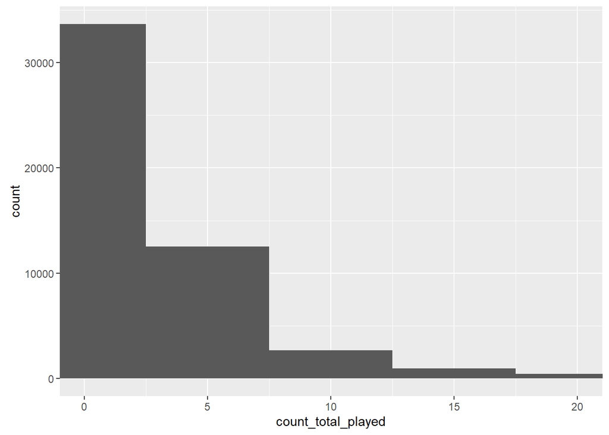

```r
p1 <- g + geom_histogram(mapping = aes(x = count_total_played), binwidth = 5) +
  coord_cartesian(xlim = c(0, 20))

p1
```

## task: make scatter plots

Plot the relationship between `count_total_played` and `count_rec_played` using:

- geom_point (setting `alpha=0.1`)

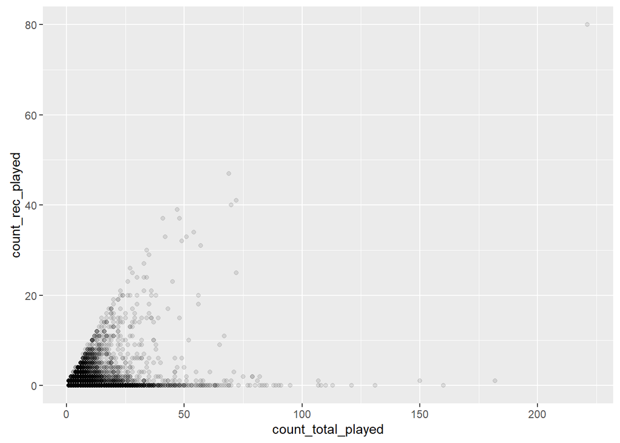

```r
p2 <- g + geom_point(mapping = aes(x = count_total_played, y = count_rec_played), alpha = 0.1)

p2
```

- geom_jitter

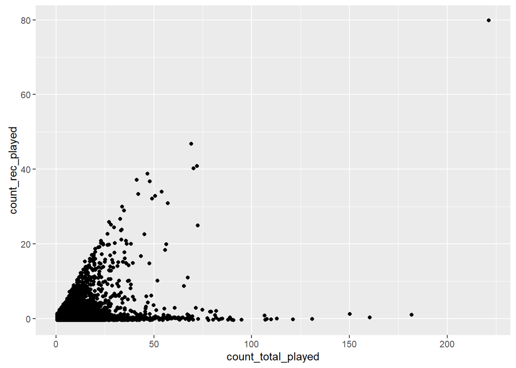

```r
p3 <- g + geom_jitter(mapping = aes(x = count_total_played, y = count_rec_played))

p3
```

- geom_count

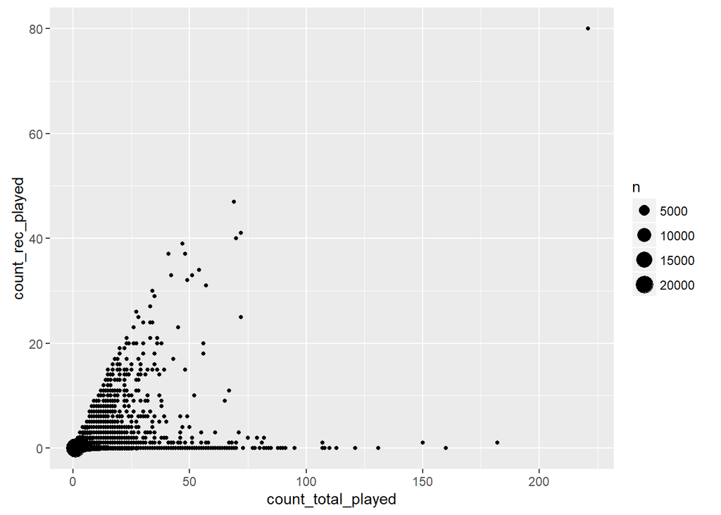

```r
p4 <- g + geom_count(mapping = aes(x = count_total_played, y = count_rec_played))

p4
```

Also:

- use a `facet_wrap` to split the chart by algorithm

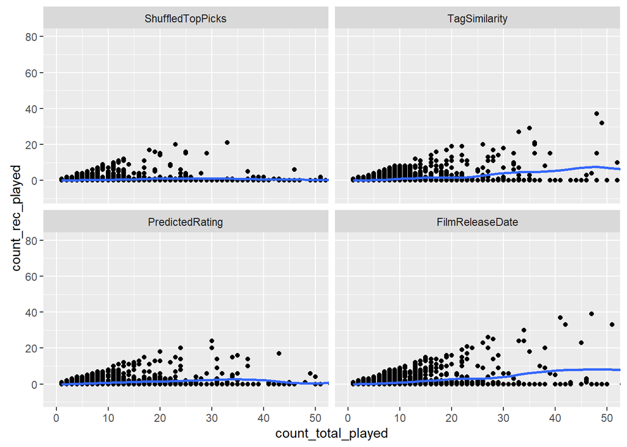

```r
p5 <- g + geom_point(mapping = aes(x = count_total_played, y = count_rec_played)) +
  geom_smooth(mapping = aes(x = count_total_played, y = count_rec_played)) +
  coord_cartesian(xlim = c(0, 50)) +
  facet_wrap( ~ Algorithm)

p5
```

## summary stats

Here are aggregate stats of recommended play actions, grouped by algorithm:

```r
trailer_activities_summary <- trailer_activities %>%
  group_by(Algorithm) %>%
  summarise(
    total_played = n(),
    mean_rec_played = mean(count_rec_played),
    max_rec_played = max(count_rec_played),
    min_rec_played = min(count_rec_played),
    std_err_rec_played = sd(count_rec_played)/sqrt(n())
  )
trailer_activities_summary
```

| Algorithm | total_played | mean_rec_played | max_rec_played | min_rec_played | std_err_rec_played |
| --- | --- | --- | --- | --- | --- |
| ShuffledTopPicks | 12659 | 0.1094873 | 21 | 0 | 0.006456752 |
| TagSimilarity | 12828 | 0.2172591 | 47 | 0 | 0.012184213 |
| PredictedRating | 12664 | 0.1762476 | 80 | 0 | 0.010469805 |
| FilmReleaseDate | 12730 | 0.2203456 | 40 | 0 | 0.012950569 |

## task: make a bar chart!

Are the number of observations balanced between the four experimental algorithms? Build a bar chart of this tibble by Algorithm.

```r
g1 <- ggplot(data = trailer_activities_summary)
```

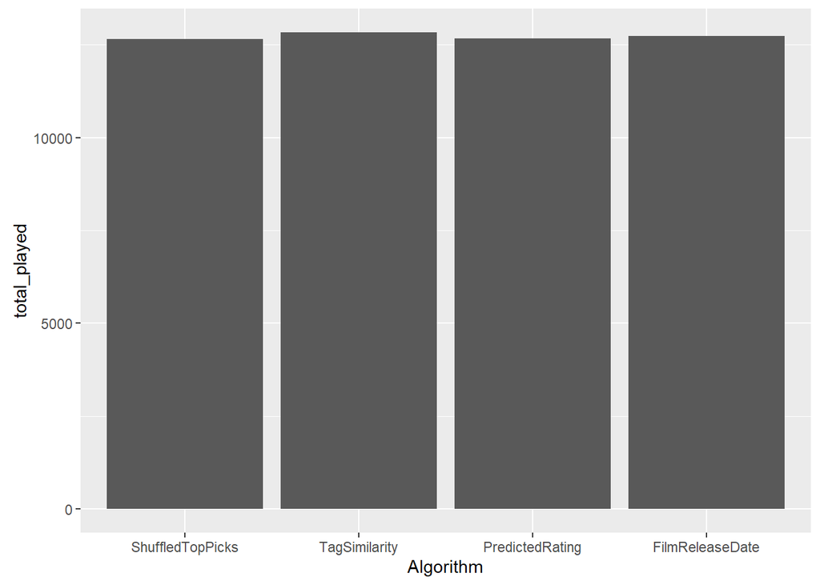

```r
p6 <- g1 + geom_bar(mapping = aes(x = Algorithm, y = total_played), stat = "identity")

p6
```

- use `geom_col`, charting Algorithm by mean_rec_played

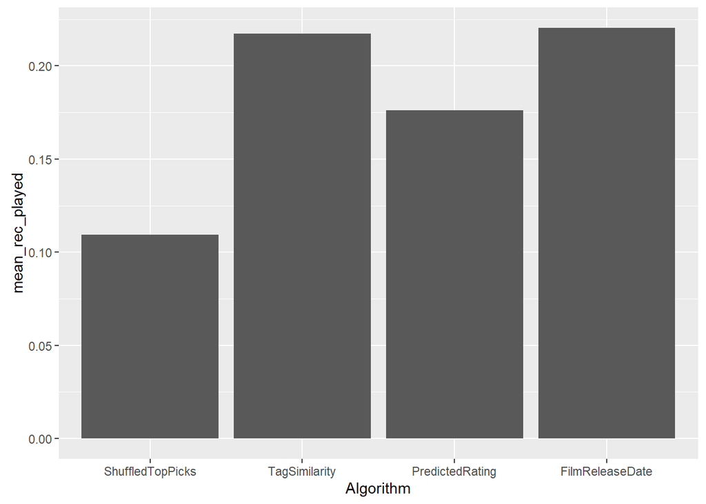

```r
p7 <- g1 + geom_bar(mapping = aes(x = Algorithm, y = mean_rec_played), stat = "identity")

p7
```

- try adding another geom: `geom_errorbar(aes(ymin = mean_rec_played - std_err_rec_played, ymax = mean_rec_played + std_err_rec_played))`

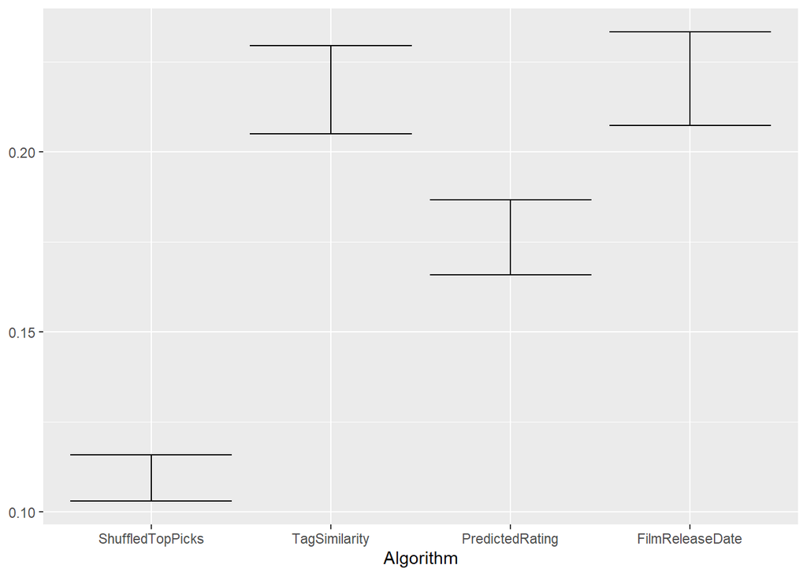

```r
p8 <- g1 + geom_errorbar(aes(x = Algorithm, ymin = mean_rec_played - std_err_rec_played, ymax = mean_rec_played + std_err_rec_played))

p8
```